# Final Project

Adham Galal and Cameron Ritchie

## 1. Background

**1.1 What’s so hard about predicting elections?**

**1.2 Nate Silver’s prediction was “righter” than others. How did he do it?**

1. Letting the data speak for itself.  
   Silver spoke on how Clinton’s polling numbers in the midwest were lower than those for the former democratic president, Obama. These poor numbers were largely dismissed by analysts, however, Silver was not so quick to do so himself. By letting the data speak for itself and investigating this trend he was able to overcome a weakness that was exposed in other models.
2. Assuming correlated errors.  
   After considering the uncertainty of lots of undecided voters and the uncertainty due to polling procedures, Silver simulated errors based on regional and demographic information. This helped him account for more errors and uncertainty, which in turn provided a more accurate representation of the population.

## 2. Data Wrangling

Before we start our analysis, we wanted to better organize the raw data into subsets. To do so we split our election data into 3 subsets; Federal, State and County. We are left with three datasets; election_federal, election_state and election (county level).

To get a general idea of the election, we plotted the vote distribution among every one of the 32 candidate of the 2016 presidential election.

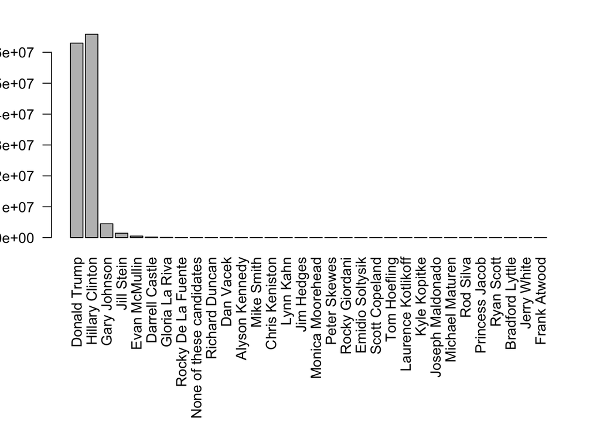

After exmaining the distribution of votes on the federal level, we thought it would be beneficial to analyse the county and state level as well. To do so we created 2 new variables; county_winner and state_winner. These variables identify the winner by finding the candidate with the highest proportion of votes on the county and state level.

## 3. Data Visualization

To better understand our data, we came up with some visuals for the county and state winners. First we start by mapping out the different counties across the country then we’ll color each county and state according to the winning candidate.

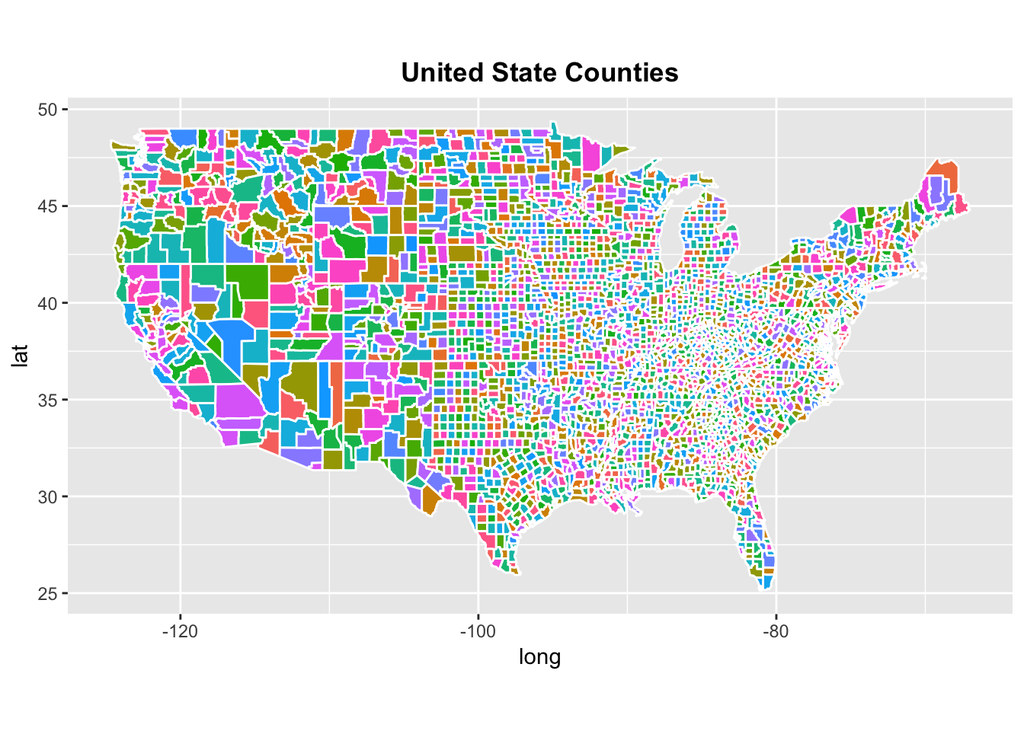

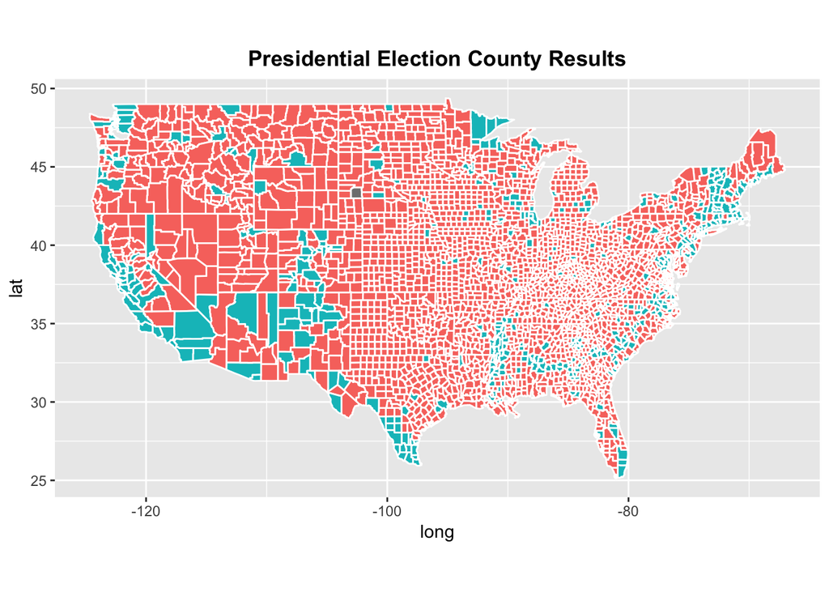

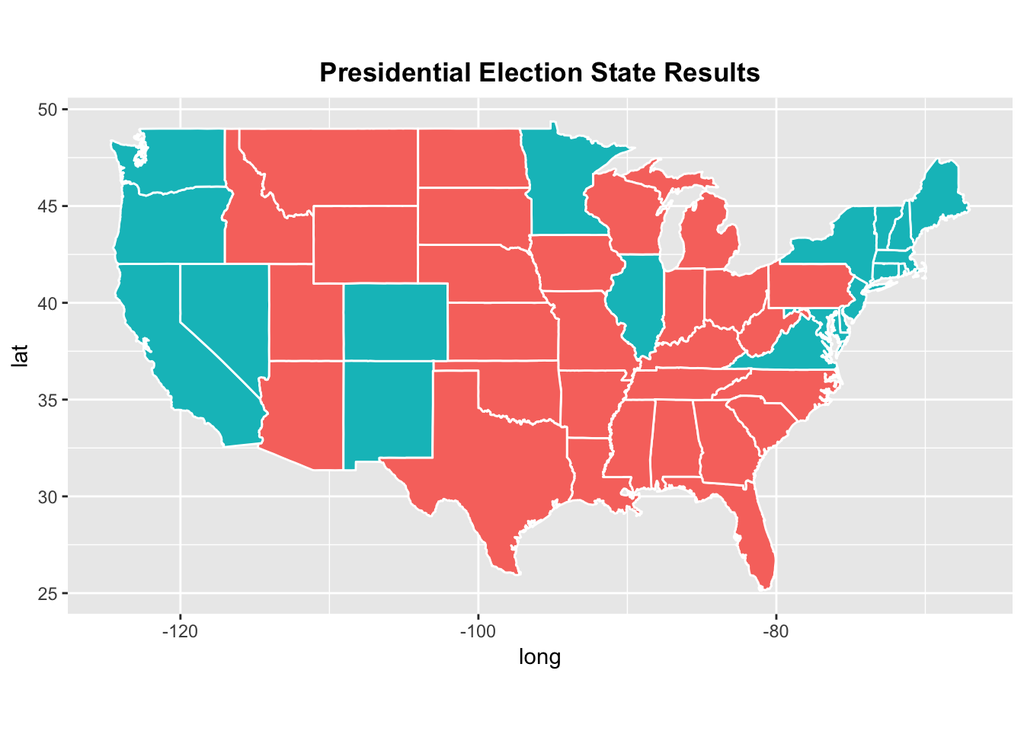

Now we’ll try to clean out some data and reduce the number of variables. Many columns seem to be related, and, if a set that adds up to 100%, one column will be deleted.

| State | County | TotalPop | Men | Hispanic | White | Black | Native | Asian | Pacific | Citizen | Income | IncomeErr | IncomePerCap | IncomePerCapErr | Poverty | ChildPoverty | Professional | Service | Office | Production | Drive | Carpool | Transit | OtherTransp | WorkAtHome | MeanCommute | Employed | PrivateWork | SelfEmployed | … |
| --- | --- | --- | --- | --- | --- | --- | --- | --- | --- | --- | --- | --- | --- | --- | --- | --- | --- | --- | --- | --- | --- | --- | --- | --- | --- | --- | --- | --- | --- | --- |
| Alabama | Autauga | 6486 | 0.4843 | 2.614 | 75.79 | 18.527 | 0.4219 | 0.9577 | 0.0161 | 0.7375 | 51696 | 7771 | 24974 | 3434 | 12.91 | 18.71 | 32.79 | 17.17 | 24.28 | 17.16 | 87.51 | 8.781 | 0.0953 | 1.3060 | 1.8357 | 26.50 | 0.4344 | 73.74 | 5.433 | … |
| Alabama | Baldwin | 7699 | 0.4885 | 4.493 | 83.10 | 9.497 | 0.5595 | 0.6647 | 0.0000 | 0.7569 | 51074 | 8745 | 27317 | 3804 | 13.42 | 19.48 | 32.73 | 17.95 | 27.10 | 11.32 | 84.60 | 8.959 | 0.1266 | 1.4438 | 3.8505 | 26.32 | 0.4405 | 81.28 | 5.909 | … |
| Alabama | Barbour | 3325 | 0.5383 | 4.628 | 46.23 | 46.691 | 0.1881 | 0.4367 | 0.0000 | 0.7691 | 32959 | 6031 | 16824 | 2430 | 26.51 | 43.56 | 26.12 | 16.46 | 23.28 | 23.32 | 83.33 | 11.057 | 0.4954 | 1.6217 | 1.5019 | 24.52 | 0.3192 | 71.59 | 7.150 | … |
| Alabama | Bibb | 6381 | 0.5341 | 2.209 | 74.50 | 21.425 | 0.4311 | 0.1006 | 0.0000 | 0.7740 | 38887 | 5662 | 18431 | 3074 | 16.60 | 27.20 | 21.59 | 17.96 | 17.47 | 23.74 | 83.43 | 13.154 | 0.5031 | 1.5621 | 0.7315 | 28.71 | 0.3669 | 76.74 | 6.638 | … |
| Alabama | Blount | 7019 | 0.4941 | 8.635 | 87.85 | 1.520 | 0.2912 | 0.1484 | 0.0000 | 0.7338 | 46238 | 8696 | 20532 | 2052 | 16.72 | 26.86 | 28.53 | 13.94 | 23.84 | 20.10 | 84.85 | 11.279 | 0.3626 | 0.4199 | 2.2654 | 34.84 | 0.3845 | 81.83 | 4.229 | … |

## 3. Dimenionality Reduction

Now that we’ve cleaned up and aggregated our census data, we’re going to analyse the variables. By doing principal compenent analysis (PCA), we will also try to reduce the variables in our data. This is essentially done by selecting the variables that differ the most from region to region, since those differences are likely to explain differences in voting behaviour regionally.

When performing PCA there is always the question of whether or not to scale and center our data. Since we have a wide range of variables measured in a wide range of units we chose to scale our data. This would mean that the variance of each variable is not relative to the type of measurement, rather the variance would be uniform for all the predictors. As for centering out data, we always favor that approach because it specifies the direction of each principal component and minimizes the chance of error.

After undergoing our analysis we found the 2 most important features are as follows:

|  | Top PC1 | Top PC2 |
| --- | --- | --- |
| County level | IncomePerCap | Asian |
| Sub-county level | IncomePerCap | Transit |

[figure not shown]

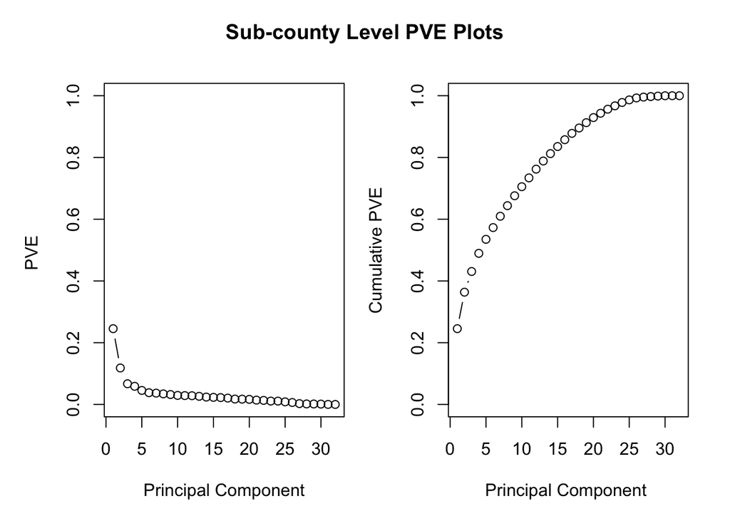

## 4. Clustering

Now we’ll try to partition the observations from the tree into 10 seperate clusters. First using the “raw” data then using only the first 2 principal components.

```
## cut.census.hclust
##    1    2    3    4    5    6    7    8    9   10
## 2991   69  119    2   20    1    2   10    3    1
```

```
## cut.ct.hclust
##  1  2  3  4  5  6  7  8  9 10
##  4  5  2  1  5  4  1  5  2  3
```

## 5. Classification

For classification we want to combine our county winners with our census data.

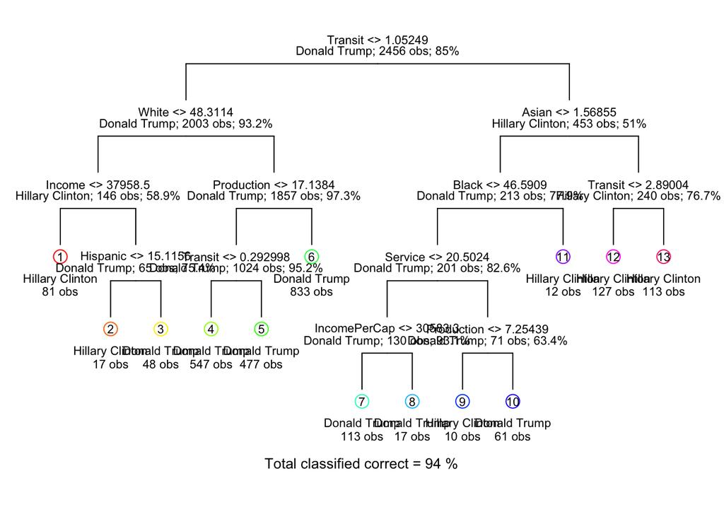

```r
#draw tree before pruning
tree.cl <- tree(candidate ~., data = trn.cl)
par(mar = c(2, 0, 0, 0))
draw.tree(tree.cl, nodeinfo = TRUE,cex = 0.7)
```

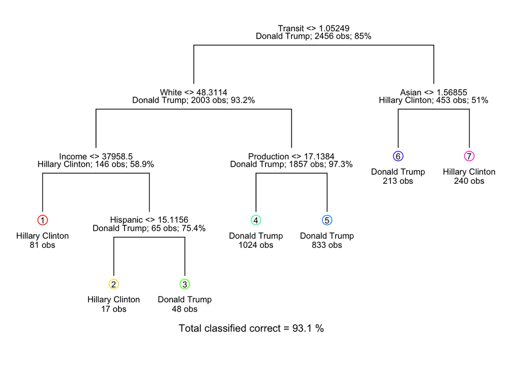

```r
#prune tree with cv.tree
tree.cl.cv <- cv.tree(tree.cl, rand = folds, K = nfold, FUN = prune.misclass)

#draw tree after pruning
opt.trees = which(tree.cl.cv$dev == min(tree.cl.cv$dev))
best.size.cv <- min(tree.cl.cv$size[opt.trees])
pruned.tree <- prune.tree(tree.cl, best = best.size.cv)
par(mar = c(2, 0, 0, 0))
draw.tree(pruned.tree, nodeinfo=TRUE, cex =0.7)
```

```r
#calculate error rates for train and test
records[1,1] <- calc_error_rate(predict(pruned.tree, data = trn.cl[,-1], type = "class"), trn.cl$candidate)
records[1,2] <- calc_error_rate(predict(pruned.tree, data = tst.cl[,-1], type = "class"), tst.cl$candidate)
```

Pruning the tree helps us understand the main demographic attributes that determine whether Clinton or Trump would win without losing too much accuracy in classification. This not only simplifies the modelbut also makes it easy to interpret. A couple of the straightforward factors affecting the election are minority percentages and average income.

Our next classification method is logistic regression. Again we’ll try to predict county votes based off demographic data.

```r
log.cl <- glm(candidate ~., data = trn.cl, family = "binomial")
summary(log.cl)
```

```
##
## Call:
## glm(formula = candidate ~ ., family = "binomial", data = trn.cl)
##
## Deviance Residuals:
##    Min      1Q  Median      3Q     Max
## -3.775  -0.262  -0.112  -0.042   3.554
##
## Coefficients: (1 not defined because of singularities)
##                  Estimate Std. Error z value Pr(>|z|)
## (Intercept)     -1.16e+01   1.08e+01   -1.08  0.28228
## TotalPop         2.55e-05   8.46e-05    0.30  0.76271
## Men              5.15e+00   5.59e+00    0.92  0.35726
## Hispanic        -6.22e-02   7.17e-02   -0.87  0.38539
## White           -1.92e-01   7.40e-02   -2.60  0.00943 **
## Black           -6.01e-02   7.15e-02   -0.84  0.40038
## Native          -8.86e-02   7.56e-02   -1.17  0.24099
## Asian            5.43e-02   1.11e-01    0.49  0.62504
## Pacific          1.06e+00   4.95e-01    2.15  0.03192 *
## Citizen          1.17e+01   3.74e+00    3.13  0.00175 **
## Income          -6.65e-05   2.85e-05   -2.33  0.01965 *
## IncomeErr       -5.39e-05   6.41e-05   -0.84  0.40072
## IncomePerCap     2.50e-04   6.80e-05    3.68  0.00023 ***
## IncomePerCapErr -2.77e-04   1.34e-04   -2.06  0.03911 *
## Poverty          1.68e-02   4.22e-02    0.40  0.69086
## ChildPoverty     7.20e-03   2.69e-02    0.27  0.78863
## Professional     2.56e-01   4.15e-02    6.18  6.3e-10 ***
## Service          3.46e-01   4.96e-02    6.98  3.0e-12 ***
## Office           7.58e-02   4.91e-02    1.54  0.12238
## Production       1.62e-01   4.48e-02    3.62  0.00029 ***
## Drive           -2.43e-01   5.42e-02   -4.48  7.5e-06 ***
## Carpool         -2.59e-01   6.73e-02   -3.84  0.00012 ***
## Transit         -1.58e-02   1.06e-01   -0.15  0.88202
## OtherTransp     -1.38e-01   1.04e-01   -1.33  0.18316
## WorkAtHome      -1.81e-01   7.79e-02   -2.32  0.02020 *
## MeanCommute      5.43e-02   2.60e-02    2.09  0.03698 *
## Employed         1.67e+01   3.33e+00    5.01  5.4e-07 ***
## PrivateWork      7.27e-02   2.34e-02    3.10  0.00193 **
## SelfEmployed     8.28e-03   4.73e-02    0.17  0.86121
## FamilyWork      -1.01e+00   4.03e-01   -2.49  0.01268 *
## Unemployment     1.82e-01   4.02e-02    4.53  6.0e-06 ***
## minority               NA         NA      NA       NA
## CountyTotal      7.65e-08   3.77e-07    0.20  0.83929
## ---
## Signif. codes:  0 '***' 0.001 '**' 0.01 '*' 0.05 '.' 0.1 ' ' 1
##
## (Dispersion parameter for binomial family taken to be 1)
##
##     Null deviance: 2074.96  on 2455  degrees of freedom
## Residual deviance:  837.47  on 2424  degrees of freedom
## AIC: 901.5
##
## Number of Fisher Scoring iterations: 7
```

```r
#calculating training error
prob.train <- predict(log.cl, data = trn.cl[,-1], type = "response")
prob.train <- as.factor(ifelse(prob.train >= 0.5, "Hillary Clinton", "Donald Trump"))
true.value.train <- trn.cl$candidate
true.value.train <- factor(true.value.train, levels = c("Donald Trump", "Hillary Clinton"))
records[2,1] <- calc_error_rate(prob.train, true.value.train)

#calculating test error
prob.test <- predict(log.cl, data = tst.cl[,-1], type = "response")
prob.test <- as.factor(ifelse(prob.test >= 0.5, "Hillary Clinton", "Donald Trump"))
true.value.test <- tst.cl$candidate
true.value.test <- factor(true.value.test, levels = c("Donald Trump", "Hillary Clinton"))
records[2,2] <- calc_error_rate(prob.test, true.value.test)
```

Finally, we’ll run K-fold cross validation and select the best regularization parameter for the logistic regression. We’ll use LASSO as our penalty and work to minimize that parameter.

```r
#fitting cv.glmnet
x <- model.matrix(candidate~., trn.cl)[,-1]
y <- ifelse(trn.cl$candidate=="Donald Trump",1,0)
set.seed(10)
lasso.cl <- cv.glmnet(x, y, alpha = 1, family = "binomial")

#best regularization parameter
bestlam <- lasso.cl$lambda.1se
bestlam
```

```
## [1] 0.003631
```

```r
#coefficients
lambda.train = glmnet(x,y,alpha = 1, family = "binomial")
lasso.coef = predict(lambda.train, type = "coefficients", s = bestlam)
lasso.coef
```

```
## 33 x 1 sparse Matrix of class "dgCMatrix"
##                          1
## (Intercept)      1.701e+01
## TotalPop         .
## Men              .
## Hispanic         .
## White            8.617e-02
## Black           -1.996e-02
## Native           1.011e-02
## Asian           -1.608e-01
## Pacific         -3.963e-01
## Citizen         -9.791e+00
## Income           .
## IncomeErr        5.990e-06
## IncomePerCap    -2.957e-05
## IncomePerCapErr  .
## Poverty         -1.429e-02
## ChildPoverty     .
## Professional    -1.385e-01
## Service         -2.175e-01
## Office           .
## Production      -9.837e-03
## Drive            7.564e-02
## Carpool          6.475e-02
## Transit         -9.037e-02
## OtherTransp      .
## WorkAtHome       .
## MeanCommute      .
## Employed        -1.268e+01
## PrivateWork     -5.312e-02
## SelfEmployed     .
## FamilyWork       3.923e-01
## Unemployment    -1.227e-01
## minority         .
## CountyTotal     -2.682e-07
```

```r
#training error
lasso.pred.train <- predict(lasso.cl, s = bestlam, newx = x, type = "response")
lasso.pred.train <- as.factor(ifelse(lasso.pred.train >= 0.5, "Donald Trump", "Hillary Clinton"))
lasso.true.train <- trn.cl$candidate
lasso.true.train <- factor(lasso.true.train, levels = c("Donald Trump", "Hillary Clinton"))
records[3,1] <- calc_error_rate(lasso.pred.train, lasso.true.train)

#test error
x.test <- model.matrix(candidate~., tst.cl)[,-1]
lasso.pred.test <- predict(lasso.cl, s = bestlam, newx = x.test, type = "response")
lasso.pred.test <- as.factor(ifelse(lasso.pred.test >= 0.5, "Donald Trump", "Hillary Clinton"))
lasso.true.test <- tst.cl$candidate
lasso.true.test <- factor(lasso.true.test, levels = c("Donald Trump", "Hillary Clinton"))
records[3,2] <- calc_error_rate(lasso.pred.test, lasso.true.test)

print(records)
```

```
##       train.error test.error
## tree      0.06922    0.25407
## log       0.06311    0.25448
## lasso     0.07085    0.07655
```

We see that the LASSO method gives us the least test error and is a lot more consistent with the training error, meaning it both fits the training data and the test data well. It follows that the tree and log-regression classification are a lot more bias since they fit the training data really well but poorly fit the test data.